# Effects of automatic and manual transmission on MPG

Pete Schnettler

February 20, 2016

## Executive Summary

Motor Trend magazine has been providing automotive information to their subscribers and interested in answering two questions about fuel efficiency and transmission selection for their readers. Specifically:

- Is an automatic or manual transmission better for MPG?
- Quantify the MPG difference between automatic and manual transmissions

Utilizing linear regression, this paper will study whether there is a material difference in miles per gallon between cars that have automatic transmissions verses those with manual transmissions.

## Data Processing and transformation

For this analysis we will use the mtcars dataset and transform variables into factors

```r
data(mtcars)
mtcars$cyl  <- factor(mtcars$cyl)
mtcars$vs   <- factor(mtcars$vs)
mtcars$gear <- factor(mtcars$gear)
mtcars$carb <- factor(mtcars$carb)
mtcars$am   <- factor(mtcars$am,labels=c("Automatic","Manual"))
str(mtcars)
```

```
## 'data.frame':    32 obs. of  11 variables:
##  $ mpg : num  21 21 22.8 21.4 18.7 18.1 14.3 24.4 22.8 19.2 ...
##  $ cyl : Factor w/ 3 levels "4","6","8": 2 2 1 2 3 2 3 1 1 2 ...
##  $ disp: num  160 160 108 258 360 ...
##  $ hp  : num  110 110 93 110 175 105 245 62 95 123 ...
##  $ drat: num  3.9 3.9 3.85 3.08 3.15 2.76 3.21 3.69 3.92 3.92 ...
##  $ wt  : num  2.62 2.88 2.32 3.21 3.44 ...
##  $ qsec: num  16.5 17 18.6 19.4 17 ...
##  $ vs  : Factor w/ 2 levels "0","1": 1 1 2 2 1 2 1 2 2 2 ...
##  $ am  : Factor w/ 2 levels "Automatic","Manual": 2 2 2 1 1 1 1 1 1 1 ...
##  $ gear: Factor w/ 3 levels "3","4","5": 2 2 2 1 1 1 1 2 2 2 ...
##  $ carb: Factor w/ 6 levels "1","2","3","4",..: 4 4 1 1 2 1 4 2 2 4 ...
```

## Exploratory Analysis

### Model Selection

In order to determine the predictors, we will start with building a model with all of the variables as predictors and perform all-subsets regression using the leaps( ) function from the leaps package. Finnaly, the car library will be used to look at the adjusted r Square values for combinations of variables.

```r
library(leaps)
attach(mtcars)
leaps <- regsubsets(mpg ~ ., data = mtcars, nbest=1)
library(car)
subsets(leaps, statistic = "adjr2", legend=c(20, 20))
```

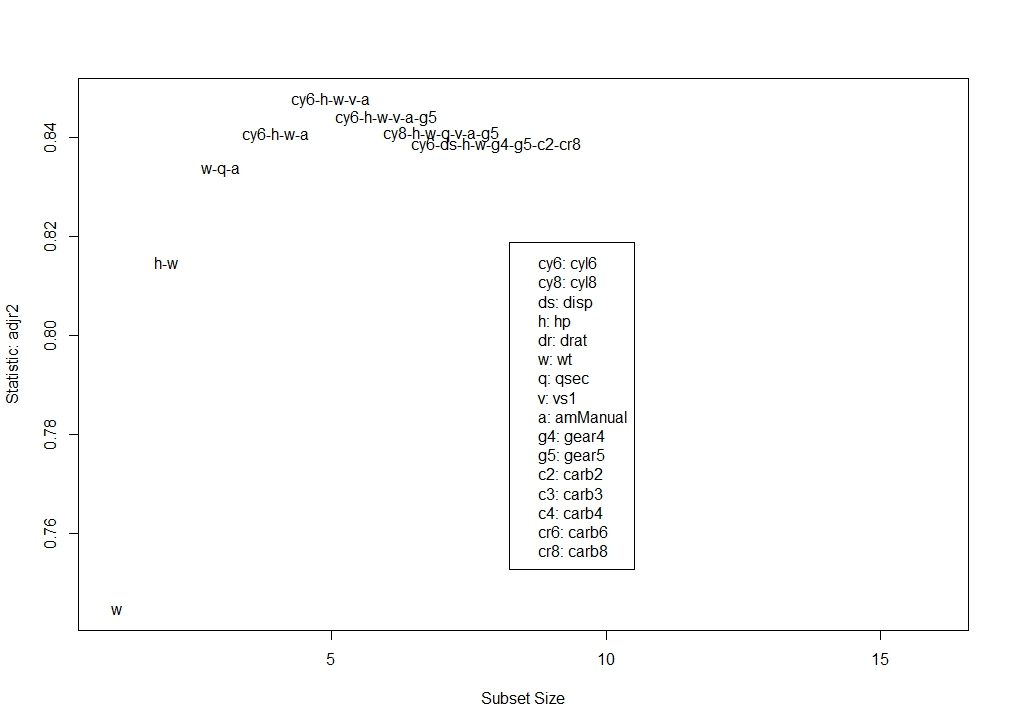

```r
data(mtcars)
fit <- lm(mpg~., data = mtcars)
library(relaimpo)
```

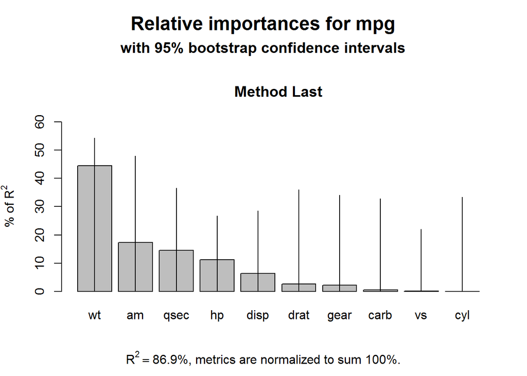

```r
relimp <- calc.relimp(fit,type=c("last"),rela=TRUE)
boot <- boot.relimp(fit, b = 100, type = c("last"), rank = TRUE, diff = TRUE, rela = TRUE)
plot(booteval.relimp(boot,sort=TRUE))
```

From the plot above, “am” which represents automatic vs manual, ranks second in relative importance for mpg behind weight.